# Устойчивость объёмного отклика сердца при уточнении FEM-сетки

**Статус: вычислительный эксперимент; первый этап численной проверки продолжается.**

## Что проверено и какой результат получен

Выполнены 25 новых электрических решений: 15 на уточнённой сетке и 10 контрольных на исходной. С учётом пяти ранее полученных решений индивидуальной формы в основном сравнении двух сеток сопоставлены 30 состояний. Во всех случаях использовано по 16 384 точки интегрирования в элементах, для которых требуется численное вычисление доли материала.

Для индивидуальной формы на уточнённой сетке при изменении объёма на ±0,5% получены односторонние оценки **-11,61 и -20,22 мОм/мл**. Центральная оценка составляет **-15,92 мОм/мл**. Эллипсоид оказался ближе к индивидуальной форме, чем сфера, на обеих сетках. Предпочтение сохранилось в **6 из 6** проверенных сочетаний направления оценки и шага. Это описательная проверка на двух сетках, без вывода о статистической значимости.

Предыдущая постановка, способы построения фигур и результаты первого блока приведены в отчёте 40.17. Настоящий отчёт отвечает на более узкий вопрос: насколько изменяются электрический отклик и сравнительные выводы при уточнении внутренней сетки.

## 1. Постановка вычислительного эксперимента

Использована одна статическая индивидуальная модель Nix, диагональная сборка TEPC-2 с четырьмя конечными контактами диаметром 5 мм, полная электродная модель (CEM) и частота 50 кГц. Свойства тканей заданы расчётными значениями; они не являются индивидуальными измерениями. Удельный контактный импеданс перенесён из прежнего сравнения проекта и также не измерен для данного опыта. Сердечная область представляет целое эффективное сердце — смесь крови и миокарда. Модель проводимости действительная, скалярная; ёмкостная составляющая не учитывается.

Положение и форма контактов, наружная поверхность тела, свойства тканей и геометрия каждой сердечной модели между сетками сохранены. Уточнены только внутренние элементы. Поэтому сравнение характеризует внутреннюю дискретизацию поля при неизменной дискретизации поверхности и контактов.

| Исходная геометрическая величина | Значение |
| --- | --- |
| Объём целого эффективного сердца, мл | 782,891854 |

| Компартмент | ρ, Ом·м |
| --- | --- |
| Мягкие ткани | 12,975453 |
| Эффективное целое сердце | 3,271862 |
| Лёгкие | 6,779277 |
| Кости | 48,445126 |

| Контактный параметр | Значение |
| --- | --- |
| Диаметр, мм | 5,0 |
| Номинальная площадь, мм² | 19,634954 |
| Удельный контактный импеданс, Ом·м² | 0,0001591549 |
| Доля номинальной площади | 1,00 |

| Сетка | Фактические площади четырёх контактов, мм² |
| --- | --- |
| Исходная сетка | 20,0923; 20,1552; 19,7529; 19,8520 |
| Уточнённая сетка | 20,0923; 20,1552; 19,7529; 19,8520 |

| Сетка | Узлы | Тетраэдры |
| --- | --- | --- |
| Исходная сетка | 791141 | 4448426 |
| Уточнённая сетка | 821731 | 4630591 |

Фон принят неподвижным: исходная область сердца заполнена мягкими тканями, лёгкие и кости сохранены как отдельные материалы. Текущая сердечная область накладывается на этот фон; при её уходе восстанавливается прежний фоновый материал. Пересечение с лёгкими или костями не отклоняет состояние. Это согласованное допущение о материальной карте, без механической деформации окружающих органов.

Индивидуальная форма задана объединением исходных сердечных тетраэдров. Сфера сохраняет исходный объём; эллипсоид построен по вторым моментам и приведён к тому же объёму. Для каждой формы заданы пять состояний: исходное и изменения объёма −1%, −0,5%, +0,5%, +1%. Масштабирование равномерное, центр неподвижен; у эллипсоида сохраняются ориентация и отношения полуосей. Это численные пробы, а не принятые физиологические амплитуды сердечного цикла.

На обеих сетках отдельно собраны материальные матрицы средствами EIDORS. Старые матрицы на новые состояния не перенесены. Учтено частичное заполнение тетраэдра сердечным материалом; поле аппроксимируется линейными функциями. Проверены невязка решения, баланс тока, взаимность, контрольные суммы входов и неизменность расчётной геометрии контактов. Эти проверки не заменяют физическую валидацию модели.

## 2. Базовый импеданс и изменение сигнала

Базовый импеданс сравнивается при одной и той же форме на двух сетках. Для анализа реакции на объём из каждого состояния вычитается собственный базовый импеданс той же формы и той же сетки:

$$\Delta Z_G(\varepsilon)=Z_G(V_0(1+\varepsilon))-Z_G(V_0).$$

Здесь $G$ обозначает форму, $V_0$ — её исходный объём, $\varepsilon$ — заданное относительное изменение объёма. Поэтому постоянный сдвиг базового импеданса не переносится автоматически в ошибку изменения сигнала.

| Форма | Z исходной сетки, Ом | Z уточнённой сетки, Ом | Различие, Ом | Различие, % |
| --- | --- | --- | --- | --- |
| Индивидуальная форма | 165,798449 | 166,417493 | 0,619044 | 0,373 |
| Сфера | 169,479700 | 170,113988 | 0,634288 | 0,374 |
| Эллипсоид | 166,168743 | 166,806663 | 0,637920 | 0,384 |

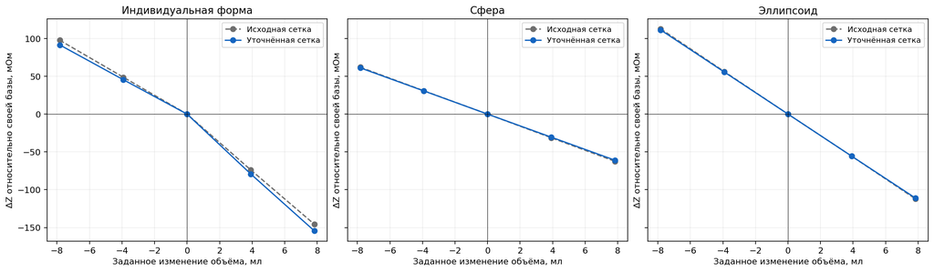

**Рисунок 1. Изменение импеданса при одинаковом изменении объёма.** В каждом графике сопоставлена одна форма на двух сетках. Вертикальная координата — изменение относительно собственной базы. Наклоны и расстояние между кривыми показывают, сохраняется ли реакция на объём после уточнения поля; сами базовые уровни приведены отдельно в таблице. Шкала вертикальной оси одинакова во всех панелях. Соединяющие линии служат для чтения пяти расчётных точек.

## 3. Односторонние и центральные оценки чувствительности

При положительной полуширине $\delta V$ определены

$$S_-={Z(V_0)-Z(V_0-\delta V)\over\delta V},\qquad S_+={Z(V_0+\delta V)-Z(V_0)\over\delta V},\qquad S_c={S_-+S_+\over2}.$$

Все оценки имеют единицы Ом/мл. Отрицательное значение означает уменьшение импеданса при увеличении объёма в соответствующем интервале. В знаменателе используется заданное аналитическое изменение объёма. Замена его фактическим дискретным изменением могла бы скрыть ошибку передачи геометрии в материалы.

Асимметрия в таблице определена как $A=100|S_+-S_-|/[(|S_-|+|S_+|)/2]$. Она сравнивает два направления при одном шаге; сама по себе не устанавливает ни физиологическую причину различия, ни существование единственной производной при стремлении шага к нулю.

| Форма | Сетка | Полуширина, % | S−, мОм/мл | Sс, мОм/мл | S+, мОм/мл | Асимметрия, % |
| --- | --- | --- | --- | --- | --- | --- |
| Индивидуальная форма | Исходная сетка | 0,5 | -12,4461 | -15,6465 | -18,8468 | 40,91 |
| Индивидуальная форма | Исходная сетка | 1,0 | -12,4750 | -15,5459 | -18,6168 | 39,51 |
| Индивидуальная форма | Уточнённая сетка | 0,5 | -11,6068 | -15,9155 | -20,2242 | 54,14 |
| Индивидуальная форма | Уточнённая сетка | 1,0 | -11,6866 | -15,7098 | -19,7330 | 51,22 |
| Сфера | Исходная сетка | 0,5 | -7,8816 | -7,9349 | -7,9882 | 1,34 |
| Сфера | Исходная сетка | 1,0 | -7,9176 | -7,9437 | -7,9698 | 0,66 |
| Сфера | Уточнённая сетка | 0,5 | -7,8209 | -7,8029 | -7,7849 | 0,46 |
| Сфера | Уточнённая сетка | 1,0 | -7,8129 | -7,7991 | -7,7853 | 0,35 |
| Эллипсоид | Исходная сетка | 0,5 | -14,3547 | -14,2895 | -14,2243 | 0,91 |
| Эллипсоид | Исходная сетка | 1,0 | -14,4000 | -14,3601 | -14,3201 | 0,56 |
| Эллипсоид | Уточнённая сетка | 0,5 | -14,1947 | -14,2046 | -14,2146 | 0,14 |
| Эллипсоид | Уточнённая сетка | 1,0 | -14,2130 | -14,1940 | -14,1749 | 0,27 |

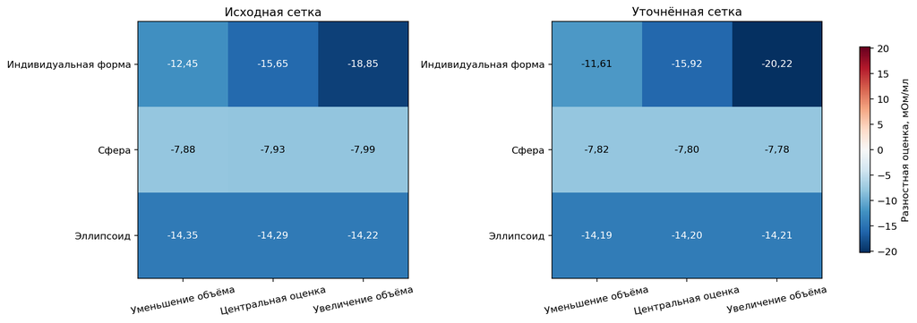

**Рисунок 2. Чувствительность трёх форм на двух сетках при полуширине 0,5%.** Цвет и подпись кодируют одну и ту же знаковую величину в мОм/мл; шкала общая. Сравнение соседних столбцов выявляет асимметрию, сравнение панелей — влияние сетки. Центральный столбец усредняет крайние и не заменяет их раздельной проверки.

В следующей таблице сеточное изменение каждой оценки вычислено как $100(S_{\mathrm{уточн}}-S_{\mathrm{исх}})/|S_{\mathrm{исх}}|$. Знак относится к численному значению оценки, а не к её модулю. Например, для отрицательной оценки отрицательное сеточное изменение означает увеличение модуля.

| Форма | Полуширина, % | Изменение S−, % | Изменение Sс, % | Изменение S+, % |
| --- | --- | --- | --- | --- |
| Индивидуальная форма | 0,5 | 6,74 | -1,72 | -7,31 |
| Индивидуальная форма | 1,0 | 6,32 | -1,05 | -6,00 |
| Сфера | 0,5 | 0,77 | 1,66 | 2,55 |
| Сфера | 1,0 | 1,32 | 1,82 | 2,31 |
| Эллипсоид | 0,5 | 1,12 | 0,59 | 0,07 |
| Эллипсоид | 1,0 | 1,30 | 1,16 | 1,01 |

## 4. Воспроизведение отклика индивидуальной формы

Для сферы и эллипсоида отдельно вычислено

$$E_G^{(d)}=100{|S_G^{(d)}-S_I^{(d)}|\over|S_I^{(d)}|},\qquad d\in\{-,c,+\},$$

где индекс $I$ обозначает индивидуальную форму. Сравнение проводится внутри одной сетки и для одинакового направления. Для односторонней оценки при одинаковом $\delta V$ это также относительная ошибка конечного изменения сигнала. Индивидуальная форма служит вычислительным ориентиром; её отклик не является экспериментальным эталоном.

Преимущество эллипсоида перед сферой описывается разностью $E_{\mathrm{сфера}}-E_{\mathrm{эллипсоид}}$. Её знак проверяется непосредственно на обеих сетках. Ошибки разных форм могут быть связаны, поэтому устойчивость их предпочтения не выводится из раздельных ошибок каждой формы и не требует предположения об их независимости.

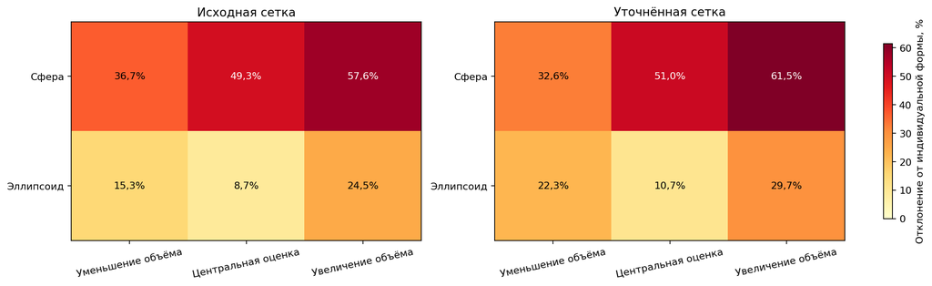

**Рисунок 3. Отклонение от индивидуальной формы при полуширине 0,5%.** Чем меньше число и светлее ячейка, тем ближе соответствующая оценка к индивидуальной форме. Обе панели используют одну шкалу. Сравниваются именно совпадения отклика, поэтому меньшая ошибка не означает большей абсолютной чувствительности сборки.

На уточнённой сетке отклонения эллипсоида составляют **22,3%** при уменьшении объёма, **10,7%** для центральной оценки и **29,7%** при увеличении. Для сферы соответственно получены **32,6%**, **51,0%** и **61,5%**. Раздельное представление этих чисел не позволяет принять близкое среднее за одинаковую точность в обоих направлениях.

## 5. Достаточность интегрирования и ограничения проверки

Одинаковое число точек интегрирования устраняет различие заданной подробности расчётов, но не доказывает одинаковой достигнутой точности. Её геометрический индикатор — отношение разности материальных объёмов двух симметричных состояний к заданной разности. В таблице приведено отклонение этого отношения от единицы, в процентах; точное значение ошибки равно нулю. Уровни 4096 и 8192 использованы здесь только для геометрической проверки. Все новые электрические решения выполнены при 16 384 точках. Два последних столбца отдельно показывают ошибку изменения материального объёма относительно исходного состояния при уменьшении и увеличении; их знаменатель — заданное одностороннее изменение объёма.

| Форма | Сетка | Полуширина, % | Ошибка при 4096, % | При 8192, % | При 16 384, % | Уменьшение при 16 384, % | Увеличение при 16 384, % |
| --- | --- | --- | --- | --- | --- | --- | --- |
| Индивидуальная форма | Исходная сетка | 0,5 | -1,7973 | -1,4590 | -0,0456 | 0,0220 | -0,1132 |
| Индивидуальная форма | Исходная сетка | 1,0 | -1,5431 | -1,4547 | -0,0452 | -0,0501 | -0,0404 |
| Индивидуальная форма | Уточнённая сетка | 0,5 | -1,5867 | -1,4554 | -0,0878 | -0,0974 | -0,0782 |
| Индивидуальная форма | Уточнённая сетка | 1,0 | -0,4796 | -0,3681 | -0,0479 | -0,0687 | -0,0272 |
| Сфера | Исходная сетка | 0,5 | -0,2568 | 0,0458 | 0,0859 | -0,1895 | 0,3612 |
| Сфера | Исходная сетка | 1,0 | -0,0388 | 0,0574 | -0,0084 | -0,1942 | 0,1774 |
| Сфера | Уточнённая сетка | 0,5 | 0,0340 | 0,0524 | 0,0226 | 0,0988 | -0,0536 |
| Сфера | Уточнённая сетка | 1,0 | 0,0214 | 0,0010 | 0,0038 | 0,0152 | -0,0077 |
| Эллипсоид | Исходная сетка | 0,5 | -0,0926 | -0,2532 | -0,2785 | -0,2850 | -0,2719 |
| Эллипсоид | Исходная сетка | 1,0 | -0,2548 | -0,0698 | -0,1470 | -0,0813 | -0,2127 |
| Эллипсоид | Уточнённая сетка | 0,5 | -0,0306 | -0,0383 | 0,0148 | -0,0748 | 0,1044 |
| Эллипсоид | Уточнённая сетка | 1,0 | -0,0106 | -0,0135 | 0,0130 | -0,0187 | 0,0447 |

Дополнительно электрические результаты исходной сетки сопоставлены с прежними решениями при 4096 точках. В таблице приведены обе односторонние и центральная оценки, а также модуль различия относительно значения при 16 384 точках. Проверено совпадение сетки, сопротивлений, контактов и исходной геометрии. Для уточнённой сетки повторное электрическое решение с другим числом точек в этот блок не входит; геометрическая таблица выше не заменяет такую проверку.

| Форма | Полуширина, % | Оценка | 4096, мОм/мл | 16 384, мОм/мл | Различие, % |
| --- | --- | --- | --- | --- | --- |
| Индивидуальная форма | 0,5 | Уменьшение объёма | -12,2129 | -12,4461 | 1,874 |
| Индивидуальная форма | 0,5 | Центральная оценка | -15,4037 | -15,6465 | 1,551 |
| Индивидуальная форма | 0,5 | Увеличение объёма | -18,5946 | -18,8468 | 1,338 |
| Индивидуальная форма | 1,0 | Уменьшение объёма | -12,2897 | -12,4750 | 1,486 |
| Индивидуальная форма | 1,0 | Центральная оценка | -15,3463 | -15,5459 | 1,284 |
| Индивидуальная форма | 1,0 | Увеличение объёма | -18,4029 | -18,6168 | 1,149 |
| Сфера | 0,5 | Уменьшение объёма | -7,9076 | -7,8816 | 0,330 |
| Сфера | 0,5 | Центральная оценка | -7,9412 | -7,9349 | 0,080 |
| Сфера | 0,5 | Увеличение объёма | -7,9748 | -7,9882 | 0,168 |
| Сфера | 1,0 | Уменьшение объёма | -7,9870 | -7,9176 | 0,876 |
| Сфера | 1,0 | Центральная оценка | -7,9806 | -7,9437 | 0,464 |
| Сфера | 1,0 | Увеличение объёма | -7,9742 | -7,9698 | 0,055 |
| Эллипсоид | 0,5 | Уменьшение объёма | -14,4624 | -14,3547 | 0,750 |
| Эллипсоид | 0,5 | Центральная оценка | -14,3345 | -14,2895 | 0,314 |
| Эллипсоид | 0,5 | Увеличение объёма | -14,2065 | -14,2243 | 0,125 |
| Эллипсоид | 1,0 | Уменьшение объёма | -14,4661 | -14,4000 | 0,459 |
| Эллипсоид | 1,0 | Центральная оценка | -14,4055 | -14,3601 | 0,316 |
| Эллипсоид | 1,0 | Увеличение объёма | -14,3450 | -14,3201 | 0,173 |

Для оценки пространственных масштабов: радиус равновеликой сферы составляет 57,17 мм. Увеличение её объёма на 0,5% смещает сферическую границу всего на 0,095 мм. Медиана длин уникальных рёбер элементов исходной сердечной области составляет 16,25 мм на исходной сетке и 8,67 мм на уточнённой. Эти длины описывают выбранную область и не являются оценкой электрической ошибки.

Такое сопоставление показывает, почему уточнение долей материала и уточнение поля проверяются отдельно: перемещение границы может быть значительно меньше размера элемента. Линейные функции внутри него имеют постоянный градиент и не описывают скачок градиента внутри пересечённого элемента. Из одного отношения размеров нельзя установить величину ошибки или причину наблюдаемой асимметрии.

Во всех 30 сравниваемых состояниях проверки решения пройдены. Максимальная относительная невязка составила 2.54e-11 при допуске 1e−7; максимальное абсолютное расхождение взаимных импедансов — 1.57e-09 Ом, меньше даже абсолютной части допуска 1e−8 Ом. Максимальная ошибка баланса тока составила 1.14e-13 А при допуске 1e−7 А. Это подтверждает решение заданных дискретных систем с принятой точностью; ошибка геометрии и пространственной аппроксимации оценивается отдельно.

Малая ошибка изменения материального объёма не является верхней границей электрической ошибки: разные участки границы имеют разную чувствительность. Одновременно малая невязка линейной системы характеризует точность решения дискретной задачи, а не близость этой задачи к непрерывной модели.

## 6. Практический вывод и следующий шаг

**Для следующего этапа сравнения предпочтителен эллипсоид.** Это рекомендация для данного способа построения, одной модели Nix и сборки TEPC-2. При полуширине 0,5% на уточнённой сетке центральная оценка эллипсоида отличается от индивидуальной на 10,7%, а сферы — на 51,0%. Результат поддерживает дальнейшую проверку эллипсоида, но ещё не разрешает заменять им сердце при количественном восстановлении объёма: ошибки двух направлений составляют 22,3% и 29,7%.

Равенство объёмов само по себе не обеспечивает равенства электрического отклика. Сфера в этом опыте воспроизводит примерно половину модуля центральной оценки индивидуальной формы. Эллипсоид сохраняет также вытянутость и ориентацию формы, поэтому представляет более содержательное геометрическое приближение. Однако данный опыт не разделяет влияние этих признаков и положения отдельных участков границы; приписывать улучшение одному из них пока нельзя.

Уточнение сетки изменило центральную оценку индивидуальной формы по модулю на 1,72%, а односторонние оценки — на 6,74% и 7,31%. Асимметрия выросла с 40,9% до 54,1%. Следовательно, центральная оценка скрывает часть сеточной изменчивости. Индивидуальную форму необходимо сохранять как вычислительный ориентир и проверять оба направления раздельно. Этот опыт не устанавливает превосходство эллипсоида над всеми методами построения сферы из реестра: здесь использована только одна равновеликая сфера.

В этом блоке непосредственно проверены изменения сигнала и предпочтение форм на двух сетках при одинаковой подробности интегрирования. Числа в таблицах позволяют раздельно оценить три эффекта: изменение базового импеданса, изменение реакции на объём и расхождение упрощённой формы с индивидуальной.

**Двух уровней внутренней сетки недостаточно для заявления о доказанной пространственной сходимости.** Допустимая ошибка итоговой оценки функции сердца заранее не задана; наблюдаемые различия не превращаются автоматически в критерий пригодности. Наружная сетка и дискретизация контактов в этом опыте не уточнялись. Не выполнены физическая валидация, совмещение статической КТ с 4D-КТ, переносы сердца, другие сборки, состояния сопротивлений или участники.

Следующий проверочный расчёт должен уточнить область движущейся границы ещё раз и проследить изменения конечного сигнала и обеих односторонних оценок. Отдельный контроль с одинаковым фоновым материалом около границы позволит исследовать, какая часть асимметрии связана с неоднородным фоном. Основная постановка с мягкими тканями, лёгкими и костями при этом сохраняется. Причины асимметрии пока не разделены.

Только после численной проверки имеет смысл расширять геометрическую задачу на движение по данным 4D-КТ. Ни изменение объёма целого эффективного сердца, ни объём эквивалентной сферы в данном опыте не интерпретируются как ударный объём желудочка или фракция выброса.